# Snowshoe Hares in Bonanza Creek

Gabriel De La Rosa

2/1/2020

## Exploring Snowshoe Hare population in the Bonanza Creek Experimental Forest

Snowshoe Hares are a keystone prey species in boreal forests. Snowshoe hare population density influences the ecosystem in both bottom-up and top-down ways: hare population density is linked to both vegetation abundance and predator abundance (Stenseth et al, 1997). Here, snowshoe hare weights and population density are compared through time.

Data were obtained from the [Bonanza Creek Experimental Forest Long Term Ecological Research Program](https://portal.lternet.edu/nis/metadataviewer?packageid=knb-lter-bnz.55.22).

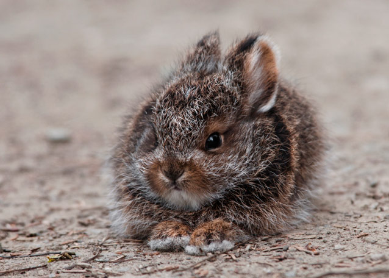

Baby snowshoe hare. NPS Photo

### Results

```r
# Read in necessary packages

library(tidyverse)
library(janitor)
library(lubridate)
library(gridExtra)
library(ggridges)
library(naniar)
library(ggpubr)
library(viridis)
library(kableExtra)
library(here)
```

```r
# Read in the data

snowshoe <- read_csv(here("data", "showshoe_lter.csv")) %>%
  select(-time)

# Make dates dates, and clean up some entries

snowshoe_date <- snowshoe %>%
  mutate(date = mdy(date)) %>%
  mutate(month = month(date)) %>%
  mutate(year = year(date)) %>%
  mutate(grid = tolower(grid)) %>%
  mutate(age = tolower(age)) %>%
  mutate(sex = tolower(sex))
```

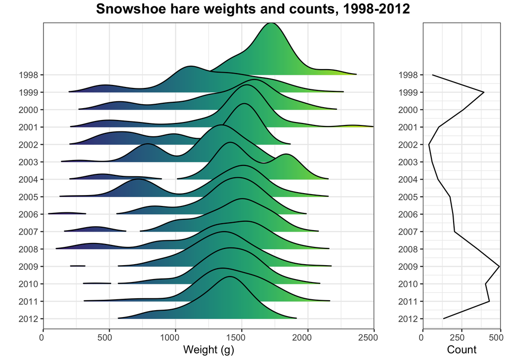

**Fig. 1** *Density plot showing snowshoe hare weight distrubutions per year, from 1998 to 2012 (left plot). Second plot shows total counted hares per year (right plot).*

```r
# Let's explore snowshoe hare weights over time
# Select for just weight and dates

weight_yr <- snowshoe_date %>%
  select(date, weight, year)

# And, I'll just explore this with a quick histogram

ggplot(data = weight_yr, aes(x = weight)) +
  geom_histogram()

# And then break weight distribution down by year using a ridgeline plot

weight_plot <-
ggplot(data = weight_yr, aes(x = weight,
                               y = fct_rev(as.factor(year)),
                               fill = stat(x))
       ) +

  geom_density_ridges_gradient(scale = 3,
                      rel_min_height = 0.01) +
  theme_bw() +

  labs(y = "",
       x = "Weight (g)") +

  theme(legend.position = "null",
        axis.text.x = element_text(hjust = 0.8)) +

  scale_fill_viridis() +

  scale_x_continuous(limits = c(0, 2500),
                     expand = c(0,0))


# This would be cool with a total population size plot next to it
# Let's count the observations per year

year_count <- weight_yr %>%
  group_by(year) %>%
  count()

# Then plot

year_plot <-

  ggplot(data = year_count, aes(x = year, y = n)) +
  geom_line() +

  coord_flip() +
  theme_bw() +
  scale_x_reverse(limits = c(2012.6, 1995),
                  expand = c(0,0),
                  breaks = seq(from = 2101, to = 1998, by = -1))+

  scale_y_continuous(breaks = c(0, 250, 500),
                     limits = c(0, 500),
                     expand = c(0,0)) +
  labs(x = "",
       y = "Count") +
  theme(axis.text.x = element_text(hjust = 0.8))

# Put the plots next to each other using ggarrange()

wt_count <-

ggarrange(weight_plot,
          year_plot,
          ncol = 2,
          widths = c(3,1))

# Then add a title using fig_annotate

fig_annotate <- annotate_figure(wt_count,
                top = text_grob("Snowshoe hare weights and counts, 1998-2012",
                                size = 14,
                                face = "bold"))

fig_annotate

ggsave("wt_fig.png", plot = fig_annotate)
```

Weight distrubution for adult snowshoe hares remained relatively stable between 1998 and 2012 (Fig 1). High density of low-weight hares, likely indicating a juvenile-skewed demogaphic, often preceeded population rebounds (eg. in 2002 and 2003). However, a low-weight population in 1999 actually preceeded a significant population decline. Cyclic hare growth is characteristic of the predator-prey interaction model, where periods of high prey growth are followed by significant predator population increases, which then cause prey population decline.

```r
# Let's make a table of mean weights per year, with standard deviations and hare counts per year

# First, select and summarize our data so it will look nice in a table

hare_table <- weight_yr %>%
  select(-date) %>%
  group_by(year) %>%
  summarize(mean = round(mean(weight, na.rm = TRUE), 2),
            stdev = round(sd(weight, na.rm = TRUE), 2),
            n = n())

# And then make a table using kableExtra

hare_table <- kable(hare_table,
      col.names = c("Year", "Mean (g)", "Standard Deviation", "Number of Observations"))%>%
      kable_styling(bootstrap_options = c("striped"),
                    full_width = F) %>%
      add_header_above(header = c("Average Yearly Hare Weights" = 4)) %>%
  scroll_box(width = "100%", height = "200px")
```

| Average Yearly Hare Weights Year | Average Yearly Hare Weights Mean (g) | Average Yearly Hare Weights Standard Deviation | Average Yearly Hare Weights Number of Observations |
| --- | --- | --- | --- |
| 1998 | 1704.75 | 179.61 | 60 |
| 1999 | 1250.38 | 392.53 | 392 |
| 2000 | 1376.64 | 401.62 | 260 |
| 2001 | 1390.21 | 405.16 | 102 |
| 2002 | 1201.57 | 417.69 | 38 |
| 2003 | 1212.72 | 310.42 | 59 |
| 2004 | 1472.16 | 376.84 | 97 |
| 2005 | 1269.00 | 407.61 | 174 |
| 2006 | 1364.58 | 302.85 | 193 |
| 2007 | 1371.70 | 346.12 | 203 |
| 2008 | 1317.25 | 395.38 | 351 |
| 2009 | 1337.73 | 272.28 | 491 |
| 2010 | 1392.84 | 251.94 | 402 |
| 2011 | 1403.96 | 274.70 | 427 |
| 2012 | 1327.38 | 230.99 | 131 |

**Table 1** *Mean hare weights, standard deviation, and observations by year.*

### Citations:

Kielland, Knut; Chapin, F. Stuart; Ruess, Roger W. 2017. Snowshoe hare physical data in Bonanza Creek Experimental Forest: 1999-Present, Bonanza Creek LTER - University of Alaska Fairbanks. BNZ:55, http://www.lter.uaf.edu/data/data-detail/id/55. doi:10.6073/pasta/03dce4856d79b91557d8e6ce2cbcdc14

Nils Chr. Stenseth, Wilhelm Falck, Ottar N. Bjørnstad, Charles J. Krebs. Population regulation in snowshoe hare and Canadian lynx: Asymmetric food web configurations between hare and lynx. Proceedings of the National Academy of Sciences May 1997, 94 (10) 5147-5152; DOI: 10.1073/pnas.94.10.5147